# PA1_template

CJ

April 20, 2016

this is an attempt at using R markdown and knitr to produce an easy to read document containing R code and R output. This is for the Coursera class: Reproducible Research

# Reproducible Research: Assignment 1

## Loading and Prep of the data

Loading the Data

```r
activitydata <- read.csv("activity.csv")
```

Converting the date column to a date

```r
activitydata$date <- as.Date(activitydata$date)
```

## What is the mean total number of steps taken per day?

get total steps per day

```r
stepsperday <- tapply(activitydata$steps, activitydata$date, sum)
```

build histogram

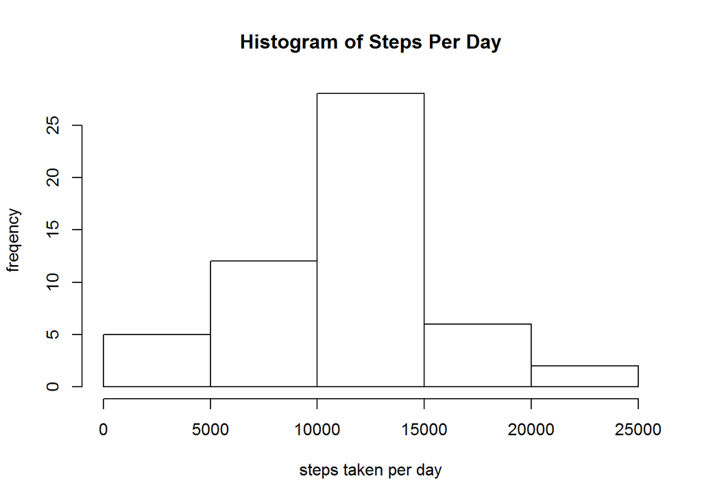

```r
hist(stepsperday, main = "Histogram of Steps Per Day", xlab = "steps taken per day", ylab = "freqency")
```

provide mean

```r
mean(stepsperday, na.rm = "TRUE")
```

```
## [1] 10766.19
```

provide median

```r
median(stepsperday, na.rm = "TRUE")
```

```
## [1] 10765
```

## What is the average daily activity pattern

Make a timeseries plot of the average steps taken per interval

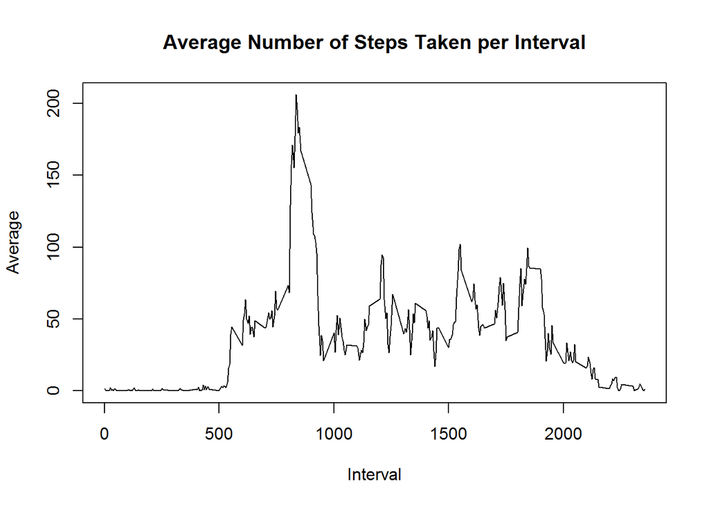

```r
intervalmean <- tapply(activitydata$steps, activitydata$interval, mean, na.rm = "TRUE")

plot(row.names(intervalmean), intervalmean, type = "l", xlab = "Interval", ylab = "Average", main = "Average Number of Steps Taken per Interval")
```

In which interval does the maximum occur?

```r
names(which.max(intervalmean))
```

```
## [1] "835"
```

## Imputing Missing Values

Find the number of missing values in the dataset

```r
sum(is.na(activitydata))
```

```
## [1] 2304
```

Devise a strategy for filling in all of the missing values in the dataset

Using the interval average to fill in gaps

```r
meansteps <- aggregate(steps ~ interval, data = activitydata, FUN = mean)
NAFill <- numeric()
for (i in 1:nrow(activitydata)) {
  observation <- activitydata[i,]
  if(is.na(observation$steps)){
    steps <- subset(meansteps, interval == observation$interval)$steps
  } else {
    steps <- observation$steps
  }
  NAFill <- c(NAFill, steps)
}
```

Create a new dataset that is equal to the original but with filled in missing data.

```r
new_data <- activitydata
new_data$steps <- NAFill
```

Make a histogram of the total number of daily steps and report the mean and median total daily steps.

```r
stepsperdayFill <- tapply(new_data$steps, new_data$date, sum)
```

And the Histogram is:

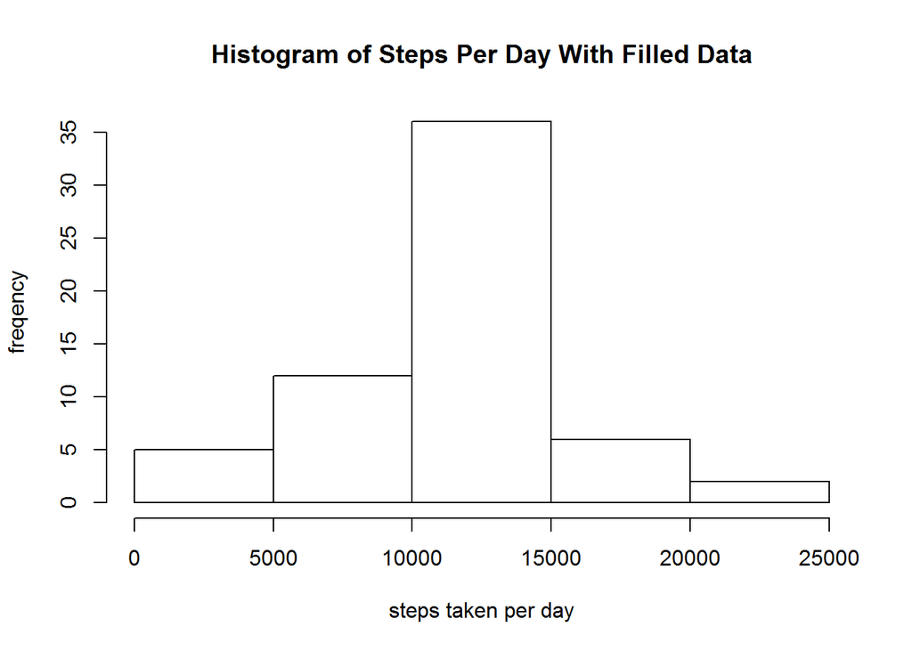

```r
hist(stepsperdayFill, main = "Histogram of Steps Per Day With Filled Data", xlab = "steps taken per day", ylab = "freqency")
```

Report on Mean of the new set

```r
mean(stepsperdayFill)
```

```
## [1] 10766.19
```

Report on Median of the new set

```r
median(stepsperdayFill)
```

```
## [1] 10766.19
```

Filling the NA values has had no impact on the daily average but a slight impact on the median.

## Are there any differences in activity patterns between weekdays and weekends

Create a new factor variable in the dataset with two levels “weekday”" and “weekend”

```r
day <- weekdays(activitydata$date)
daylevel <- vector()
for(i in 1:nrow(activitydata)){
  if(day[i] == "Sunday"){
    daylevel[i] <- "weekend"
  } else if (day[i] == "Saturday"){
    daylevel[i] <- "weekend"
  } else{
    daylevel[i] <- "weekday"
  }
}

activitydata$daylevel <- daylevel
activitydata$daylevel <- factor(activitydata$daylevel)

stepsbyday <- aggregate(steps ~ interval + daylevel, data = activitydata, mean)
names(stepsbyday) <- c("interval", "daylevel", "steps")
```

Make a panel plot comparing weekday activity against weekend activity.

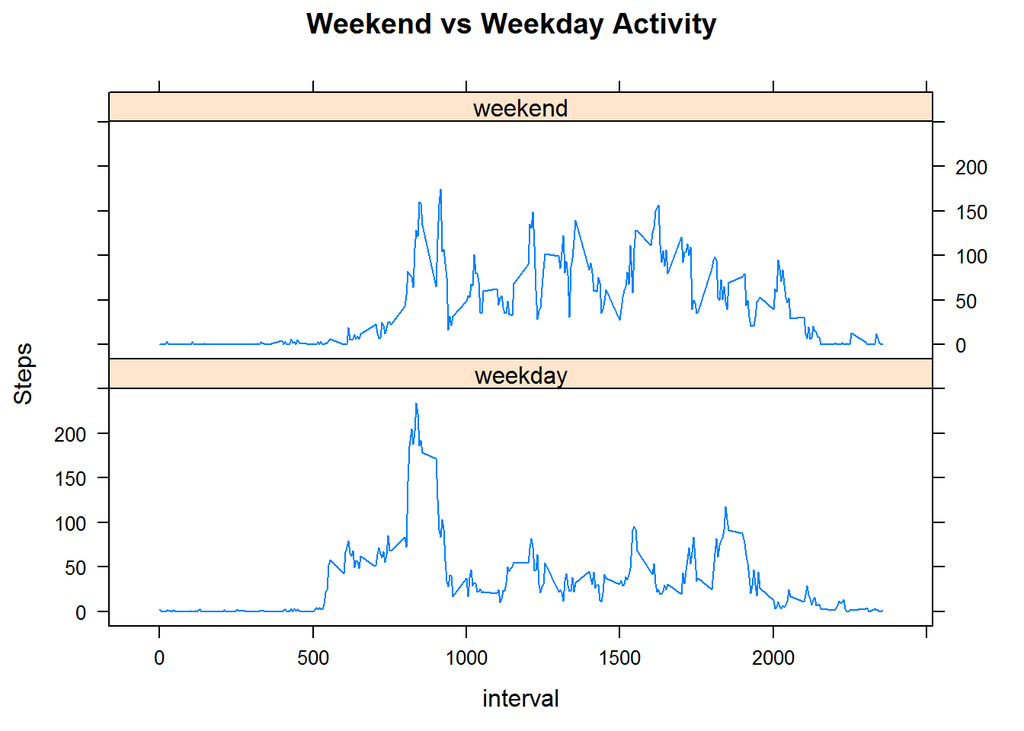

```r
library(lattice)
xyplot(steps ~ interval | daylevel, stepsbyday, type = "l", layout = c(1, 2), main = "Weekend vs Weekday Activity", xlab = "interval", ylab = "Steps")
```